# Educación Básica y Hacinamiento en Mujeres de Edad Fértil: Región Metropolitana

Ariela Díaz Santander

2025-05-27

# 1. Introducción

Las ciudades no son espacios neutros. Su configuración responde a decisiones históricas que, en muchos casos, han sido tomadas desde una mirada hegemónica, masculina y patriarcal. Esta lógica de planificación ha generado entornos urbanos que no siempre reflejan ni responden a las necesidades, trayectorias y rutinas cotidianas de las mujeres.

Durante décadas, se relegó a las mujeres al ámbito doméstico, mientras los espacios productivos y públicos eran pensados principalmente para los hombres. Aunque en las últimas décadas las mujeres han incrementado su participación en la educación, el trabajo y el uso del espacio urbano, esta transformación no ha sido acompañada de una planificación territorial equitativa ni inclusiva.

La educación, como herramienta clave para la movilidad social y la equidad, ha mostrado avances importantes. Sin embargo, aún persisten desigualdades significativas, especialmente en territorios marcados por la precariedad social y habitacional. En este contexto, el hacinamiento se presenta como una condición estructural que limita las oportunidades de desarrollo, afectando de forma diferenciada a las mujeres.

En función de lo anterior, el presente trabajo tiene como objetivo visibilizar las desigualdades territoriales que afectan a las mujeres en edad fértil (15–49 años) en la Región Metropolitana de Santiago. Utilizando datos del Censo 2017, se analizan dos dimensiones críticas: el nivel educativo, medido mediante la razón entre mujeres con educación básica y superior, y el hacinamiento habitacional. Se busca identificar zonas donde ambas condiciones de vulnerabilidad se superponen, generando contextos de doble exclusión.

Este análisis ofrece una base territorial para comprender cómo se manifiestan las desigualdades en el espacio urbano y propone evidencias útiles para el diseño de políticas públicas con enfoque de género y justicia espacial.

## 1.1. Objetivo General

El objetivo general de este trabajo es analizar la distribución territorial de las mujeres en edad fértil con bajo nivel educativo en la Región Metropolitana, y su relación con las condiciones de hacinamiento en sus zonas de residencia.

## 1.2. Objetivos Específicos

Los objetivos específicos por trabajar son:

- Estimar un índice educativo que relacione la cantidad de mujeres con educación básica frente aquellas con educación superior en el grupo etario desde 15 a 49 años.
- Calcular el procentaje de viviendas con hacinamiento moderado o crítico.
- Respresentar espacialmente ambos indicadores a nivel de zona censal en la Provincia de Santiago.
- Identificar patrones conjuntos de vulnerabilidad mediante un análisis bivariado, con especial énfasis en zonas de doble exclusión.

Este trabajo de dividirá en Metodología, Resultados, Análisis, Conclusión y Bibliografía.

# 2. Desarrollo

## 2.1. Metodología

Para el desarrollo metodológico de este trabajo se utilizaron dos herramientas principales: **pgAdmin** y **RStudio**, con el objetivo de procesar, analizar y visualizar información proveniente del **Diccionario Censal 2017**. El análisis se centró exclusivamente en las zonas urbanas de la **Provincia de Santiago**, en la **Región Metropolitana de Santiago**, tomando como unidad de análisis la **zona censal urbana**. Esta unidad territorial permite observar diferencias intra-comunales, proporcionando un mayor nivel de desagregación espacial.

El objetivo metodológico fue calcular y representar indicadores sociales relevantes desde una perspectiva de género, enfocados en las mujeres en edad fértil (15–49 años). Se consideraron los siguientes indicadores:

1. **Razón educativa**: proporción entre mujeres con educación básica o inferior (sala cuna a enseñanza media) y mujeres con educación superior (técnica, profesional o postgrado).
2. **Porcentaje de viviendas con hacinamiento**: proporción de viviendas que presentan hacinamiento **moderado o crítico**, de acuerdo con la clasificación oficial del Censo 2017 (`ind_hacin_rec` = 2 o 4).

### **2.1.1. Librerías necesarias**

Para desarrollar el análisis en R se cargaron las siguiente librerías:

```r
library(DBI)
library(RPostgres)
library(sf)
library(ggplot2)
library(cowplot)
library(biscale)
```

Estas librerías permiten establecer conexiones con bases de datos PostgreSQL, manejar geometrías espaciales (`sf`) y generar visualizaciones estadísticas y cartográficas.

### **2.1.2. Conexión a la base de datos PostgreSQL**

Se estableció una conexión con una base de datos local en PostgreSQL que contiene las tablas del Censo 2017 para la Región Metropolitana.

Y las variables consideradas fueron:

- `p08`: Sexo.
- `p09`: Edad.
- `p15`: Nivel del curso más alto aprobado.
- `ind_hacin_rec` : Indicador censal de hacinamiento.

Para las mujeres de edad fértil cuyo nivel de curso más alto aprobado haya sido desde sala cuna hasta cuarto medio se realizó el siguiente filtro:

$p.p08 = 2$ $AND$ $p.p09$ $BETWEEN$ $15$ $AND$ $49$ $AND$ $p.p15 <= 7$

Que posteriormente se guardará como variable “Educación Básica”.

Para el caso de mujeres en edad fértil que tengan estudios técnicos, profesionales, magíster y/o doctorado se realizó el siguiente filtro:

$p.p08 = 2$ $AND$ $p.p09$ $BETWEEN$ $15$ $AND$ $49$ $AND$ $p.p15 > 7$

Que posteriormente será guardado como “Educación Superior”.

También se calcularon los porcentajes de viviendas con hacinamiento moderado o crítico (`ind_hacin_rec IN (2,4)`).

La consulta SQL generó una tabla con los siguientes campos por zona censal:

| Variable | Descripción |
| --- | --- |
| `geocodigo` | código único de identificación de la zona censal (clave espacial). |
| `nom_comuna` | nombre de la comuna en la que se encuentra la zona. |
| `razon_educativa` | índice porcentual entre mujeres con educación básica (p15 ≤ 7) y mujeres con educación superior (p15 > 7). Valores mayores a 1 indican predominio de mujeres con menor nivel educativo. |
| `hacinamiento` | porcentaje de viviendas en la zona censal que presentan hacinamiento moderado o crítico (según `ind_hacin_rec`). |

También se extrajo la geometría correspondiente a las zonas urbanas de la Provincia de Santiago desde la tabla `dpa.zonas_censales_rm`, seleccionando únicamente aquellas clasificadas como urbanas.

Posteriormente, se integraron los datos censales previamente procesados con la geometría espacial, generando así una tabla espacial final lista para su visualización.

Cabe destacar que la construcción de los indicadores consideró la vinculación de las tablas de viviendas, hogares y personas del Censo 2017, lo que permitió calcular el hacinamiento desde una perspectiva centrada en la vivienda, y no únicamente en las personas. Este enfoque resulta más adecuado para representar las condiciones materiales del hábitat en el territorio.

La tabla espacial resultante permite relacionar las condiciones educativas y habitacionales de las mujeres en edad fértil con su ubicación geográfica, facilitando así la generación de mapas temáticos y bivariados, los cuales se presentan y analizan en las secciones siguientes.

### 2.1.3. Indicadores

La razón educativa (*I)*, se calcula mediante la fórmula:

$$\text{Razón educativa} = \left( \frac{\text{Mujeres con educación
básica}}{\text{Mujeres con educación superior}} \right) \$$
Donde:

- *I*: Razón de mujeres en edad fértil con educación básica alcanzada sobre mujeres en edad fértil de educación superior alcanzada.

  | Naturaleza del índice *I* | Descripción |
  | --- | --- |
  | *I* < 1 | Predominan mujeres en edad fértil con educación superior alcanzada. |
  | *I* = 1 | Igual cantidad de mujeres con educación básica y superior. |
  | *I* > 1 | Predominan mujeres en edad fértil con educación básica alcanzada. |

El porcentaje de hacinamiento,

$$\text{Porcentaje de hacinamiento} = \left( \frac{\text{Viviendas con
hacinamiento (niveles 2 o 4)}}{\text{Total de viviendas}} \right) \times
100\$$

refleja las condiciones de vulnerabilidad habitacional en cada zona censal.

### 2.1.4. Visualización

1. **Mapa de razón educativa**: muestra las zonas donde predominan mujeres con menor nivel educativo.
2. **Mapa de porcentaje de hacinamiento**: identifica los territorios con mayor proporción de viviendas hacinadas.
3. **Gráfico de dispersión**: relaciona ambos indicadores, permitiendo observar zonas de doble exclusión (alto rezago educativo y alto hacinamiento).
4. **Mapa bivariado**: combina ambos indicadores en una visualización compuesta, facilitando la identificación de zonas con simultánea precariedad educativa y habitacional, entregando evidencia útil para el diseño de políticas con enfoque de género y territorial.

## 2.2 Análisis y Resultados

Del procesamiento de la base de datos del censo en pgAdmin y porteriormente en RStudio, se obtuvieron los siguientes dos mapas que se muestran a continuación:

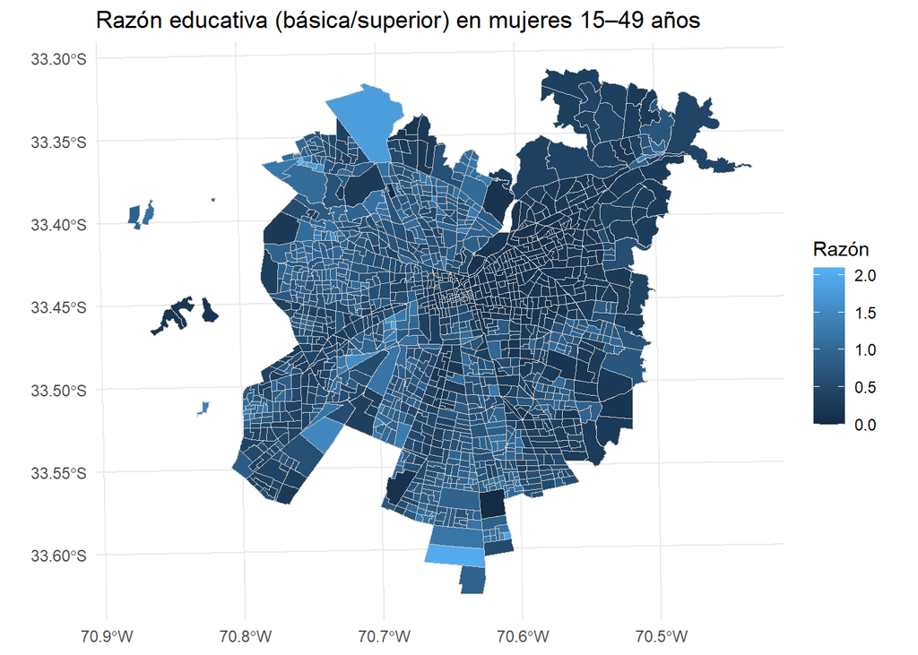

Este mapa representa la **razón educativa**, calculada como la relación entre mujeres con educación básica e intermedia respecto a aquellas con educación superior en el grupo etario de 15 a 49 años. El índice se construyó a partir de la fórmula explicada en la sección de Metodología, donde:

- Un valor **menor a 1** indica que predominan mujeres con educación superior.
- Un valor **igual a 1** refleja paridad entre ambos niveles.
- Un valor **mayor a 1** señala predominancia de mujeres con solo educación básica o media.

A nivel espacial, se aprecia un patrón **claro en las zonas periféricas del sur y poniente**, como **La Pintana, San Ramón, El Bosque y Lo Espejo**, reflejando una fuerte **desigualdad educativa** que afecta principalmente a sectores de bajos ingresos y alta vulnerabilidad social. También aparecen zonas claras en **barrios céntricos antiguos**, donde reside población adulta mayor con trayectorias educativas más cortas.

En contraste, **las zonas del sector oriente de Santiago**, como **Las Condes, Vitacura y Providencia**, presentan tonalidades oscuras, evidenciando una alta proporción de mujeres con estudios superiores. Estas comunas se asocian con mejores condiciones de vida, alto nivel socioeconómico y amplia oferta de educación superior.

Se observa un **gradiente educativo** desde la periferia al centro, especialmente al ingresar al **anillo de Américo Vespucio**, donde comienzan a predominar valores intermedios, indicando un equilibrio entre mujeres con educación básica y superior. A medida que se avanza hacia el centro y oriente, los valores disminuyen por debajo de 1, reflejando mayor nivel educativo en mujeres jóvenes que han accedido a estudios técnicos o universitarios.

Un quiebre importante ocurre en **Santiago Centro**, donde los valores vuelven a subir hacia el sur, y luego disminuyen claramente hacia el norte y oriente. Este fenómeno muestra cómo las **desigualdades educativas** se expresan espacialmente dentro de una misma comuna, debido a la **segmentación socioeconómica y residencial**.

Cabe destacar que uno de los factores estructurales que afecta la continuidad de estudios en mujeres jóvenes es el **embarazo adolescente**, especialmente en zonas más vulnerables. Según la ex subsecretaria Paula Daza (2017), “El embarazo adolescente es un indicador de vulnerabilidad, sobre todo en menores de 15 años. Son menores que forman hogares monoparentales, generalmente quedan solas y dejan de estudiar, se les dificulta trabajar, entonces el efecto que tiene esto en la pobreza es muy grande”.

En conclusión, este mapa no solo muestra la distribución territorial del nivel educativo de las mujeres, sino que también **visibiliza las inequidades estructurales** que afectan sus trayectorias de vida y oportunidades futuras. Constituye una herramienta geodemográfica clave para focalizar políticas públicas con enfoque de género, territorio y equidad educativa.

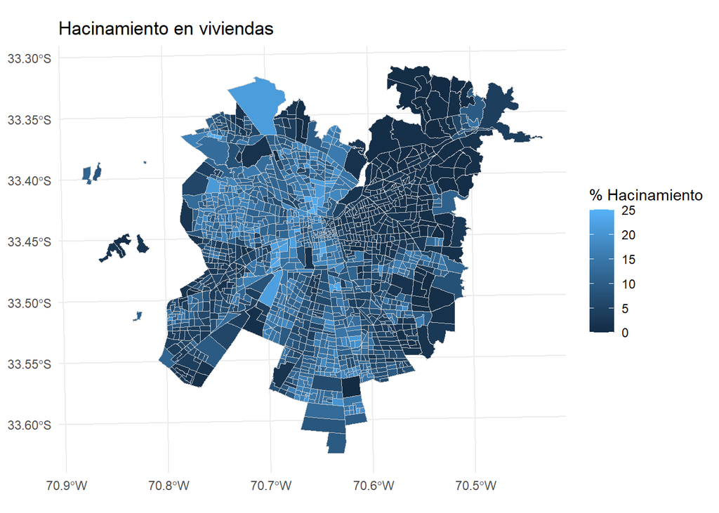

El presente mapa muestra la distribución territorial del **hacinamiento en viviendas** en la Región Metropolitana de Santiago, medido como el porcentaje de viviendas que presentan condiciones de hacinamiento dentro de cada zona censal. El indicador refleja la proporción de hogares con más de 2,5 personas por dormitorio, siguiendo los estándares utilizados por el Censo 2017.

El hacinamiento no solo representa un déficit cuantitativo de vivienda, sino que también está vinculado a **condiciones estructurales de pobreza, exclusión y vulnerabilidad**. Las zonas más afectadas por este fenómeno suelen coincidir con territorios que presentan altos niveles de precariedad socioeconómica, elevada densidad poblacional, y presencia significativa de hogares monoparentales y/o migrantes.

Según el informe de IdeaPaís (2022), más del 60% de las personas que viven en hacinamiento en Chile se concentran en la Región Metropolitana. Este fenómeno se configura como un problema estructural, asociado a la **falta de planificación urbana**, la **especulación del suelo** y la **insuficiente oferta de viviendas sociales adecuadas**.

Además, como señala el Centro de Estudios del Mineduc (2022), las condiciones de hacinamiento tienen efectos directos sobre otras dimensiones del bienestar, como la **educación**, dificultando los procesos de estudio, descanso y desarrollo integral, especialmente en hogares con niños, niñas y adolescentes.

El mapa pone en evidencia la necesidad de **intervenciones focalizadas** que aborden el hacinamiento no solo desde una lógica de construcción de viviendas, sino también desde una **perspectiva integral de bienestar urbano**. Esto implica articular políticas de vivienda con estrategias de desarrollo territorial, acceso equitativo a servicios públicos, y programas de apoyo a las familias en situación de vulnerabilidad.

Asimismo, este análisis cobra especial relevancia en el contexto de estudios de población específica, como mujeres en edad fértil (15–49 años), quienes enfrentan múltiples desventajas cuando habitan en condiciones de hacinamiento, afectando tanto su calidad de vida como la de su entorno familiar.

Con los datos obtenidos, se construye un gráfico de dispersión que representan lo observado en los mapas mostrados anteriormente.

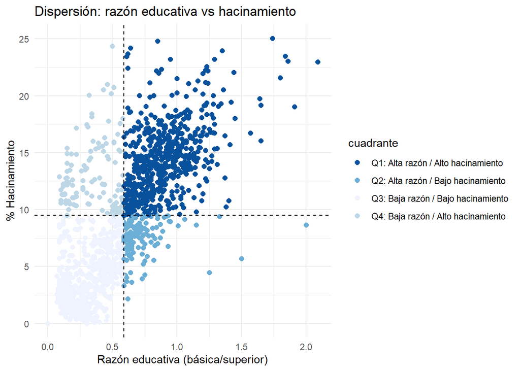

En este gráfico de dispersión se muestra la relación entre la **razón educativa** y el **porcentaje de hacinamiento** en zonas censales de la Región Metropolitana.

La **concentración de puntos en el cuadrante Q1** indica que existen múltiples zonas donde **se combinan desventajas en educación y vivienda**, reproduciendo patrones de exclusión social y precariedad.

Estos **casos extremos confirman la polarización territorial** existente en la región, donde conviven realidades profundamente contrastantes en términos de acceso a educación y condiciones de vivienda.

Aunque no se representa una línea de tendencia explícita, se advierte una **relación positiva moderada** entre ambas variables: a medida que aumenta la razón educativa (es decir, baja el nivel educativo promedio), también tiende a incrementarse el porcentaje de hacinamiento. Esta tendencia respalda la hipótesis de que **niveles educativos más bajos están asociados a mayores carencias habitacionales**, en línea con lo planteado por estudios del Mineduc (2022) y columnas académicas sobre pobreza y hacinamiento (Universidad de Chile, 2017).

Finalmente, con todo lo mencionado anteriormente, se puede generar un mapa bivariado, el cual sintetiza dos dimensiones clave del bienestar territorial: **razón educativa** y **porcentaje de hacinamiento en viviendas**. La visualización permite identificar patrones espaciales complejos y zonas críticas donde se intersectan deficiencias en educación y vivienda para mujeres en edad fértil.

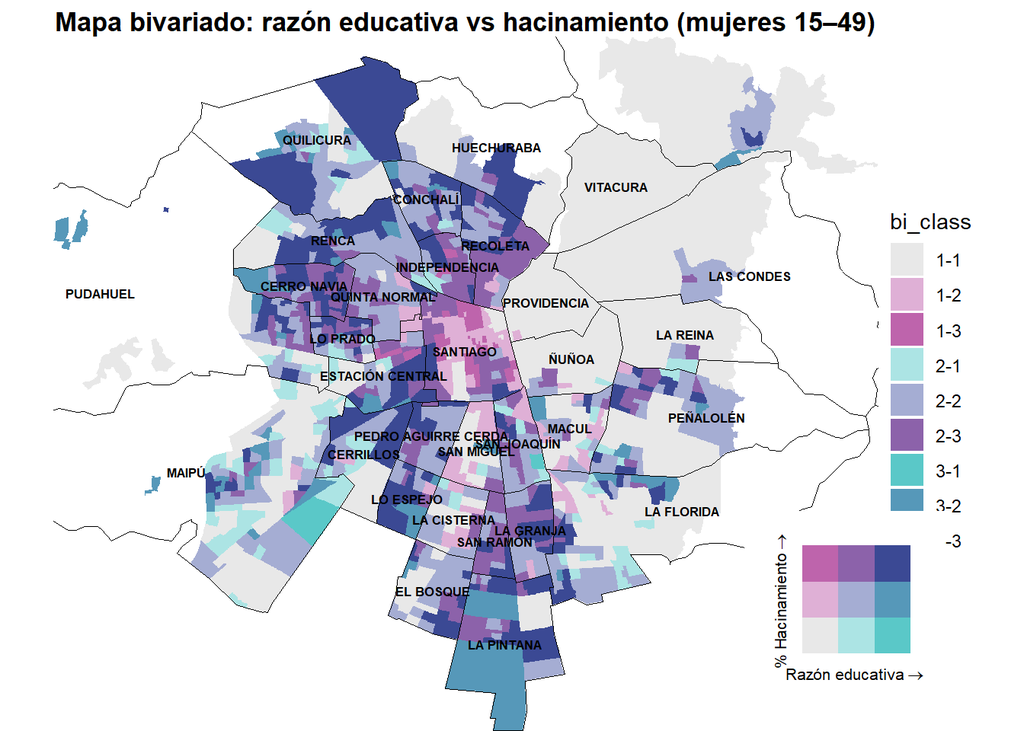

Las unidades espaciales han sido clasificadas según un sistema 3x3, resultando en **9 clases combinadas (bi_class)** que cruzan:

- El **% de hacinamiento** (eje vertical del recuadro leyenda, de claro a oscuro en el eje y).
- La **razón educativa (básica/superior)** (eje horizontal del recuadro leyenda, de claro a azul en el eje x).

Esto permite ubicar espacialmente zonas con alta, media o baja vulnerabilidad en ambas dimensiones.

Los principales hallazgos territoriales que se pueden observar son **zonas con alta vulnerabilidad educativa y habitacional** (clase 3-3, color azul oscuro). Estas comunas concentran **altos niveles de hacinamiento y bajas condiciones educativas**, lo que indica una doble desventaja estructural. Se encuentran principalmente en:

Estos territorios reflejan dinámicas de **exclusión multidimensional**, donde se reproducen condiciones de precariedad estructural que afectan especialmente a las mujeres en edad fértil.

Estas áreas muestran altos niveles de capital social y oportunidades, y reflejan la fuerte **segregación socioespacial** de la ciudad.

Y finalmente, tenemos **Zonas intermedias** (clases 2-2, 2-1, 1-2, etc.) aquí ha muchas comunas del centro de Santiago como **Estación Central**, **Santiago Centro**, **Independencia**, y **Recoleta**, presentan combinaciones intermedias, con desafíos educativos o habitacionales, pero no ambos a la vez. Estas áreas requieren atención focalizada para evitar el tránsito hacia escenarios de doble exclusión.

Por lo tanto, con este mapa se puede evidenciar una clara asociación espacial entre bajo nivel educativo y condiciones de hacinamiento, en especial en el sur y poniente de la ciudad. La superposición de estas desventajas en territorios específicos sugiere la existencia de **bolsones de exclusión territorial persistente** que requieren intervenciones multisectoriales con enfoque territorial y de género.

Hay que considerar que la herramienta bivariada es clave para priorizar zonas de intervención en políticas públicas orientadas a mejorar el acceso a la educación y la calidad de vida de las mujeres en edad fértil, así como a reducir brechas históricas entre comunas.

# 3. Conclusión

Para finalizar el trabajo realizado se pueden establecer las siguientes conclusiones:

Se cumplió satisfactoriamente el objetivo general de analizar territorialmente la relación entre hacinaiento en viviendas y la razón educativa de mujeres entre 15 y 49 años en la Región Metropolitana de Santiago, utilizando herramientas de análisis geoespacial y representación gráfica. Asimismo, se scumplieron los objetivos específicos.

Con el análisis territorial se evidenció que el hacinamiento y el rezago educativo entre mujeres de 15 a 49 años se concentran principalmente en el sector **sur y poniente** de la Región Metropolitana. A través del mapa de hacinamiento, el mapa de razón educativa, el gráfico de dispersión y el mapa bivariado, se identificaron **zonas críticas** con **doble vulnerabilidad social**, como La Pintana, El Bosque y Pedro Aguirre Cerda.

Los patrones espaciales observados reflejan desigualdades estructurales, vinculadas a factores como condiciones socioeconómicas, densidad poblacional y menor acceso a servicios y oportunidades educativas.

Finalmente, este trabajo es útil para la planificación urbana, políticas de equidad de género y evaluación de brechas territoriales. Ya que con el mapa bivariado se puede aportar un valor agregado al mostrar dónde se superponen las desigualdades, facilitando de esta forma la toma de decisiones focalizadas y multisectoriales.

# 4. Bibliografía

- Departamento de Derechos Intelectuales. (s.f.). Registros femeninos de propiedad intelectual en Chile (1886-1925). Obtenido de https://www.propiedadintelectual.gob.cl/colecciones/registros-femeninos-de-propiedad-intelectual-en-chile-1886-1925/incorporacion-de-las
- Molina, Dr. R. (13 de noviembre de 2018). Escuela de Salud Pública. Obtenido de http://www.saludpublica.uchile.cl/noticias/148998/embarazo adolescente-en-chile-sigue-a-la-baja-y-cae-a-la-mitad- #:~:text=El%20panorama%20de%20fecundidad%20precoz,218.771%20ni %C3%B1os%20en%20el%20pa%C3%ADs
- Polanco, S. G. (2018). SÍNTESIS INDICADORES EDUCACIÓN EN LA REGIÓN METROPOLITANA DE SANTIAGO: RESULTADOS ENCUESTA CASEN 2017. Santiago: Seremi de Desarrollo Social R.M.
- Servicio de Información de Educación Superior. (s.f.). Subsecretaría de Educación Superior. Obtenido de https://bibliotecadigital.mineduc.cl/bitstream/handle/20.500.12365/16821/Br echas%20Genero%20EdSup_2020.pdf?sequence=1&isAllowed=y#:~:text= El%20porcentaje%20de%20participaci%C3%B3n%20en,ha%20crecido%20 3%2C0%20p.p
- IdeaPaís. (2022). Diagnóstico sobre el hacinamiento en Chile: causas, consecuencias y propuestas. Obtenido de https://ideapais.cl/wp-content/uploads/2022/08/Ideapais_Hacinamiento.pdf
- Núñez, I. (2017). Pobreza, hacinamiento y educación. Universidad de Chile. Recuperado de https://uchile.cl/noticias/131846/columna-de-opinion-pobreza-hacinamiento-y-educacion
- Centro de Estudios MINEDUC. (2022). *Evidencias N°55: Factores asociados a la deserción escolar en jóvenes chilenos*. Ministerio de Educación de Chile. Recuperado de https://centroestudios.mineduc.cl/wp-content/uploads/sites/100/2022/11/EVIDENCIAS-55_2022_fd01.pdf
- Instituto Nacional de Estadísticas (INE). (2017). *Censo de Población y Vivienda 2017*. Recuperado de https://www.censo2017.cl